# Statistics and Financial Data Analysis - Problem Sheet 1

Prof. Samuel Cohen

Gabor Bakos | Student ID: 1031893

17/10/2016

## Note

Unfortunately due to another dealine being pushed forward I ran out of time and only did question one of the problem sheet. I will be trying to do the rest of the problem sheet after submission.

## Imprting Data

Download the files AEMOPriceDataSimple.csv and SydTemp.csv, along with the R script PS1Readin.R (which loads and formats the data). The AEMO ???le contains daily average Regional Reference Price (RRP) for New South Wales (Australia), and is adapted from http://www.aemo.com.au/Electricity/Data. The data gives the daily average spot price over 2013. The SydTemp file gives daily maximum and minimum temperatures at Observatory Hill, Sydney since 1859, and is taken from the main weather observatory http://www.bom.gov.au/climate/data-services/.

```r
library("quantmod")
AEMO<-read.csv("AEMOPriceDataSimple.csv")
SydTemp<-read.csv("SydTemp.csv")
minTemp<-SydTemp$Minimum.temperature..Degree.C.
maxTemp<-SydTemp$Maximum.temperature..Degree.C.
maxTemp<-maxTemp[SydTemp$Year==2013]
minTemp<-minTemp[SydTemp$Year==2013]
```

```r
#Assigning the variables with appropriate names:
maxTemp<-maxTemp[!is.na(maxTemp)]
minTemp<-minTemp[!is.na(minTemp)]
Date<-as.Date(AEMO$Date, '%d/%m/%y')
AEMO$day <- weekdays(as.Date(AEMO$Date, '%d/%m/%Y'))
RRP<-AEMO$RRP
```

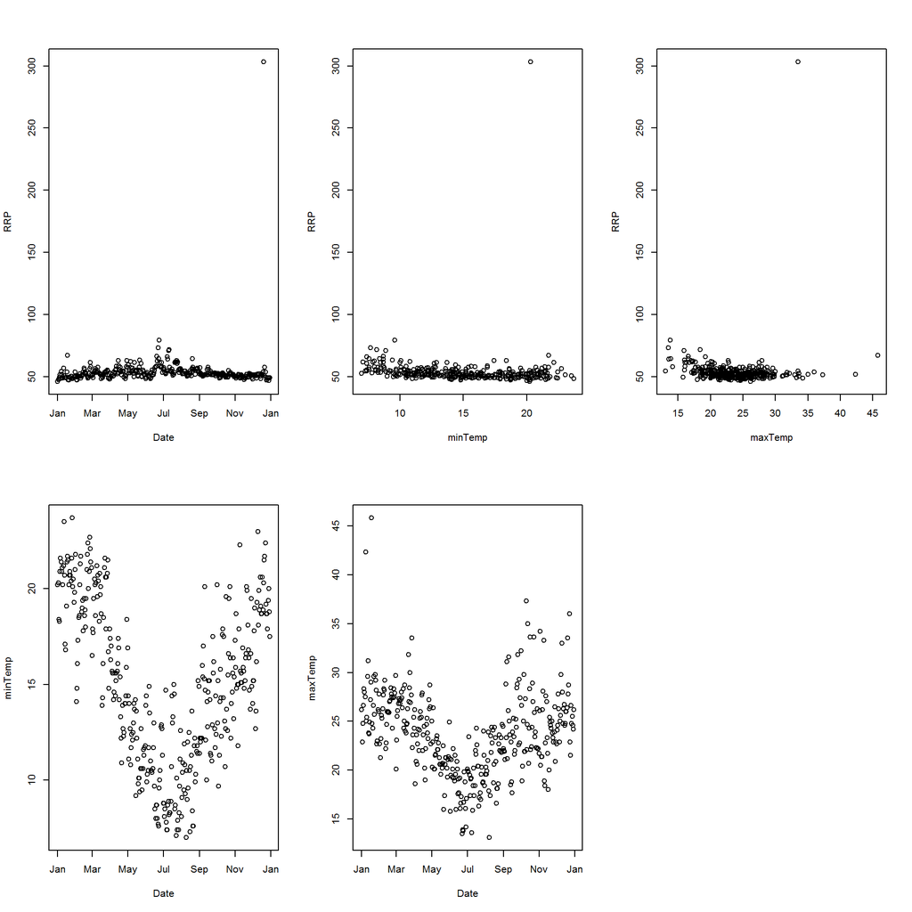

```r
#Some basic plots:
par(mfrow=c(2,3))
plot(Date,RRP)
plot(minTemp,RRP)
plot(maxTemp,RRP)
plot(Date,minTemp)
plot(Date,maxTemp)
```

```r
#Basic analysis
par(mfrow=c(2,3))
summary(RRP)
```

```
##    Min. 1st Qu.  Median    Mean 3rd Qu.    Max.
##   46.15   50.55   52.26   53.90   54.74  303.10
```

```r
sd(RRP) #standard deviation
```

```
## [1] 13.75435
```

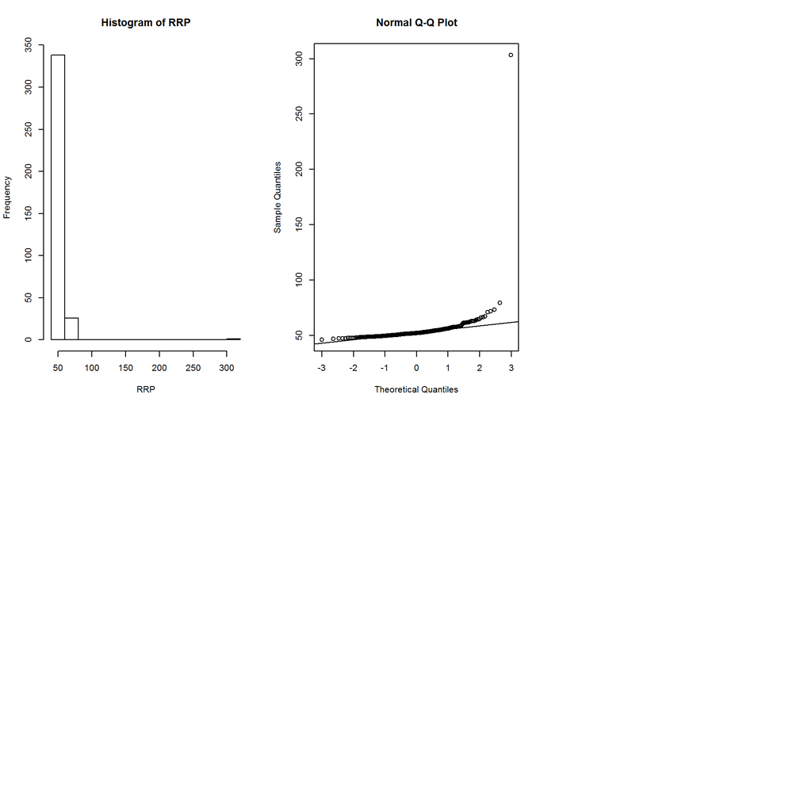

```r
hist(RRP) #histogram
qqnorm(RRP); qqline(RRP) #normal qq plot
```

There is an extereme outlier which makes it impossible to fit a good model the normal data accurately. I decided to remove this outlier but kept it in mind that extremes like that can happen occasionally.(We are trying to predict the normal day price given by weather conditions not predict what happens in extreme conditions.)

```r
#IGNORE outlier
par(mfrow=c(2,3))
Date_1<-Date[-354]
RRP_1<-RRP[-354]
minTemp_1<-minTemp[-354]
maxTemp_1<-maxTemp[-354]

summary(RRP_1)
```

```
##    Min. 1st Qu.  Median    Mean 3rd Qu.    Max.
##   46.15   50.52   52.25   53.22   54.73   79.67
```

```r
sd(RRP_1) #standard deviation
```

```
## [1] 4.258405
```

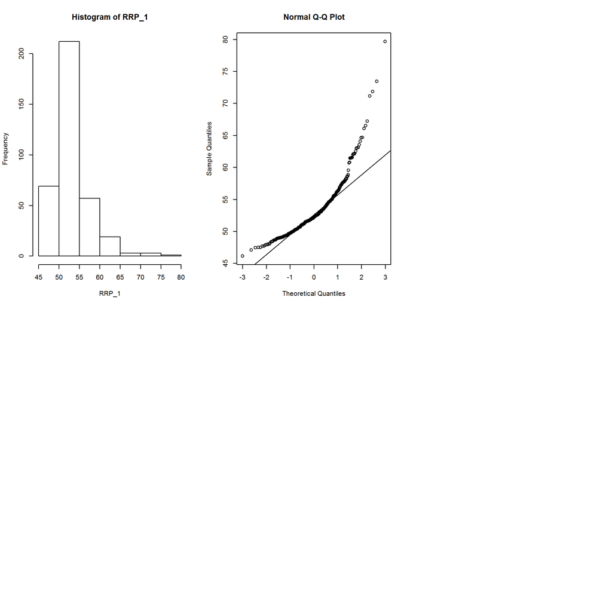

```r
hist(RRP_1) #histogram
qqnorm(RRP_1); qqline(RRP_1) #normal qq plot
```

Plotting the RRP against date, min and max temperatures and min and max temperatures against data as well.

```
##                   RRP   minTemp_1   maxTemp_1
## RRP        1.00000000 -0.04561863 -0.05255668
## minTemp_1 -0.04561863  1.00000000  0.71213266
## maxTemp_1 -0.05255668  0.71213266  1.00000000
```

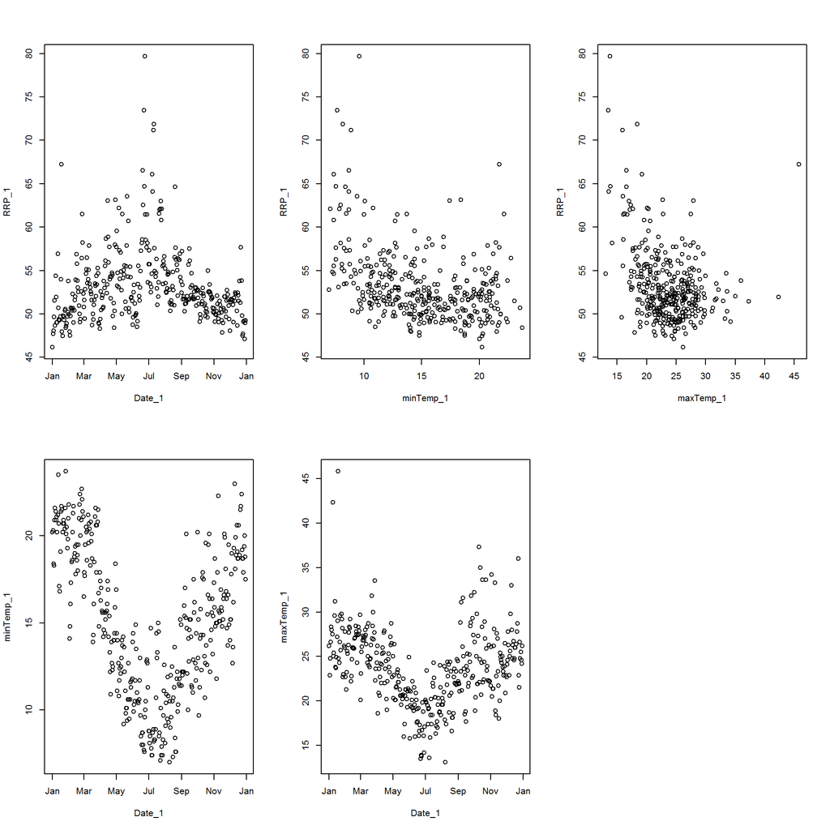

```r
par(mfrow=c(2,3))
plot(Date_1,RRP_1)
plot(minTemp_1,RRP_1)
plot(maxTemp_1,RRP_1)
plot(Date_1,minTemp_1)
plot(Date_1,maxTemp_1)

cor(cbind(RRP,minTemp_1,maxTemp_1))
```

## Linear Models

As a first step I am trying out linear models agains min temperature , max temperature and both.

```r
#maxminusminTemp_1<-maxTemp_1-minTemp_1
#minusmaxTemp_1<-minTemp_1-maxTemp_1
par(mfrow=c(2,3))


fit1<-lm(RRP_1~minTemp_1)
fit2<-lm(RRP_1~maxTemp_1)
fit3<-lm(RRP_1~minTemp_1+maxTemp_1)
#fit4<-lm(RRP_1~maxminusminTemp_1)
#fit5<-lm(RRP_1~minusmaxTemp_1)

summary(fit1)
```

```
##
## Call:
## lm(formula = RRP_1 ~ minTemp_1)
##
## Residuals:
##    Min     1Q Median     3Q    Max
## -6.335 -2.626 -0.885  1.407 24.271
##
## Coefficients:
##             Estimate Std. Error t value Pr(>|t|)
## (Intercept) 59.26364    0.76261   77.71  < 2e-16 ***
## minTemp_1   -0.40260    0.04892   -8.23 3.42e-15 ***
## ---
## Signif. codes:  0 '***' 0.001 '**' 0.01 '*' 0.05 '.' 0.1 ' ' 1
##
## Residual standard error: 3.914 on 362 degrees of freedom
## Multiple R-squared:  0.1576, Adjusted R-squared:  0.1553
## F-statistic: 67.74 on 1 and 362 DF,  p-value: 3.418e-15
```

```r
summary(fit2)
```

```
##
## Call:
## lm(formula = RRP_1 ~ maxTemp_1)
##
## Residuals:
##     Min      1Q  Median      3Q     Max
## -7.1787 -2.4978 -0.7148  1.4711 23.3039
##
## Coefficients:
##             Estimate Std. Error t value Pr(>|t|)
## (Intercept)  60.7606     1.1772  51.614  < 2e-16 ***
## maxTemp_1    -0.3184     0.0489  -6.513 2.47e-10 ***
## ---
## Signif. codes:  0 '***' 0.001 '**' 0.01 '*' 0.05 '.' 0.1 ' ' 1
##
## Residual standard error: 4.034 on 362 degrees of freedom
## Multiple R-squared:  0.1049, Adjusted R-squared:  0.1024
## F-statistic: 42.42 on 1 and 362 DF,  p-value: 2.471e-10
```

```r
summary(fit3)
```

```
##
## Call:
## lm(formula = RRP_1 ~ minTemp_1 + maxTemp_1)
##
## Residuals:
##     Min      1Q  Median      3Q     Max
## -6.4858 -2.6116 -0.9112  1.3875 23.7861
##
## Coefficients:
##             Estimate Std. Error t value Pr(>|t|)
## (Intercept) 60.30324    1.14502  52.666  < 2e-16 ***
## minTemp_1   -0.34230    0.06962  -4.917 1.34e-06 ***
## maxTemp_1   -0.08212    0.06750  -1.217    0.225
## ---
## Signif. codes:  0 '***' 0.001 '**' 0.01 '*' 0.05 '.' 0.1 ' ' 1
##
## Residual standard error: 3.911 on 361 degrees of freedom
## Multiple R-squared:  0.1611, Adjusted R-squared:  0.1564
## F-statistic: 34.65 on 2 and 361 DF,  p-value: 1.71e-14
```

```
## [1] 0.7119827
```

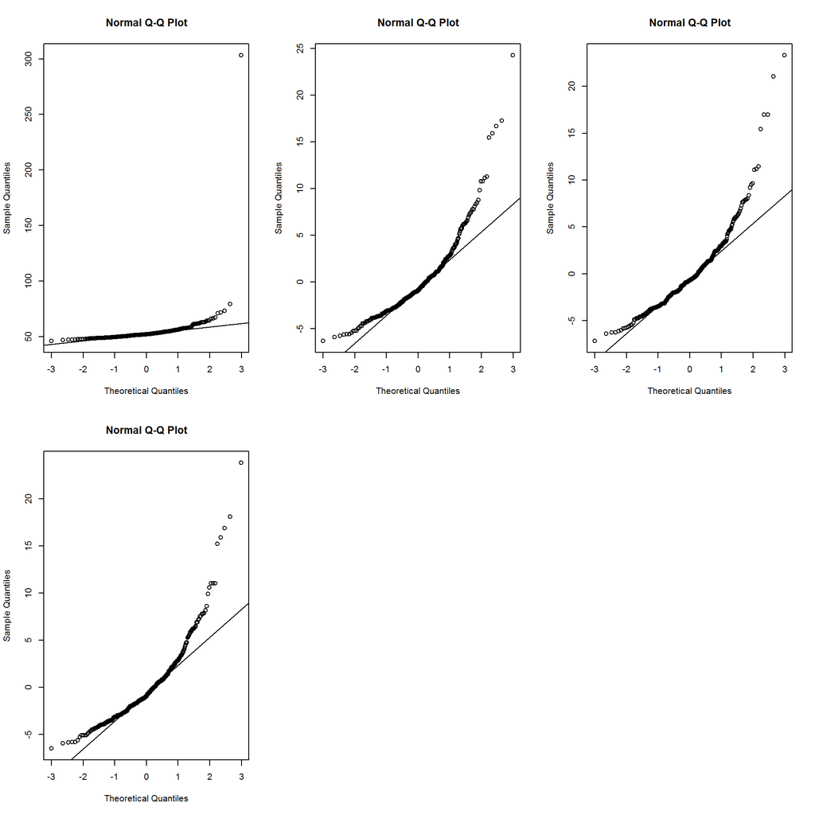

```r
#summary(fit4)
#summary(fit5)

#Normality checking#
qqnorm(RRP); qqline(RRP)
qqnorm(fit1$residuals); qqline(fit1$residuals)
qqnorm(fit2$residuals); qqline(fit2$residuals)
qqnorm(fit3$residuals); qqline(fit3$residuals)
cor(minTemp_1,maxTemp_1)
```

When trying to predict with both min and max temperatures the min is more predictive than max (there is a very high correlation between the min and max temperature hence using only one is sufficient).

The QQ plots suggest that the relation between temperature and the RRP might be non linear.

## Polinomial fits

I have tried couple of polinomial fits up to degree 10, to see whether it fits the data better.

```r
#higher dimensional
par(mfrow=c(2,1))

#higher dimensional
nl2<-lm(RRP_1~poly(maxTemp_1, degree=2))
nl5<-lm(RRP_1~poly(maxTemp_1, degree=5))
nl10<-lm(RRP_1~poly(maxTemp_1, degree=10))
summary(nl2)
```

```
##
## Call:
## lm(formula = RRP_1 ~ poly(maxTemp_1, degree = 2))
##
## Residuals:
##     Min      1Q  Median      3Q     Max
## -9.4060 -2.4868 -0.2823  1.7724 17.9674
##
## Coefficients:
##                              Estimate Std. Error t value Pr(>|t|)
## (Intercept)                   53.2185     0.1886 282.213  < 2e-16 ***
## poly(maxTemp_1, degree = 2)1 -26.2752     3.5978  -7.303 1.81e-12 ***
## poly(maxTemp_1, degree = 2)2  34.9202     3.5978   9.706  < 2e-16 ***
## ---
## Signif. codes:  0 '***' 0.001 '**' 0.01 '*' 0.05 '.' 0.1 ' ' 1
##
## Residual standard error: 3.598 on 361 degrees of freedom
## Multiple R-squared:  0.2901, Adjusted R-squared:  0.2862
## F-statistic: 73.77 on 2 and 361 DF,  p-value: < 2.2e-16
```

```r
summary(nl5)
```

```
##
## Call:
## lm(formula = RRP_1 ~ poly(maxTemp_1, degree = 5))
##
## Residuals:
##      Min       1Q   Median       3Q      Max
## -12.4366  -2.1971  -0.3703   1.4710  15.9369
##
## Coefficients:
##                              Estimate Std. Error t value Pr(>|t|)
## (Intercept)                   53.2185     0.1807 294.505  < 2e-16 ***
## poly(maxTemp_1, degree = 5)1 -26.2752     3.4476  -7.621 2.27e-13 ***
## poly(maxTemp_1, degree = 5)2  34.9202     3.4476  10.129  < 2e-16 ***
## poly(maxTemp_1, degree = 5)3 -12.8083     3.4476  -3.715 0.000236 ***
## poly(maxTemp_1, degree = 5)4  13.1627     3.4476   3.818 0.000159 ***
## poly(maxTemp_1, degree = 5)5   8.9600     3.4476   2.599 0.009739 **
## ---
## Signif. codes:  0 '***' 0.001 '**' 0.01 '*' 0.05 '.' 0.1 ' ' 1
##
## Residual standard error: 3.448 on 358 degrees of freedom
## Multiple R-squared:  0.3536, Adjusted R-squared:  0.3445
## F-statistic: 39.16 on 5 and 358 DF,  p-value: < 2.2e-16
```

```r
summary(nl10)
```

```
##
## Call:
## lm(formula = RRP_1 ~ poly(maxTemp_1, degree = 10))
##
## Residuals:
##      Min       1Q   Median       3Q      Max
## -12.7968  -2.2146  -0.3352   1.3625  16.4447
##
## Coefficients:
##                                Estimate Std. Error t value Pr(>|t|)
## (Intercept)                     53.2185     0.1791 297.174  < 2e-16 ***
## poly(maxTemp_1, degree = 10)1  -26.2752     3.4167  -7.690 1.48e-13 ***
## poly(maxTemp_1, degree = 10)2   34.9202     3.4167  10.221  < 2e-16 ***
## poly(maxTemp_1, degree = 10)3  -12.8083     3.4167  -3.749 0.000208 ***
## poly(maxTemp_1, degree = 10)4   13.1627     3.4167   3.853 0.000139 ***
## poly(maxTemp_1, degree = 10)5    8.9600     3.4167   2.622 0.009109 **
## poly(maxTemp_1, degree = 10)6   -2.6586     3.4167  -0.778 0.437020
## poly(maxTemp_1, degree = 10)7    3.8972     3.4167   1.141 0.254786
## poly(maxTemp_1, degree = 10)8   -1.9453     3.4167  -0.569 0.569478
## poly(maxTemp_1, degree = 10)9    8.5058     3.4167   2.490 0.013252 *
## poly(maxTemp_1, degree = 10)10  -6.0065     3.4167  -1.758 0.079616 .
## ---
## Signif. codes:  0 '***' 0.001 '**' 0.01 '*' 0.05 '.' 0.1 ' ' 1
##
## Residual standard error: 3.417 on 353 degrees of freedom
## Multiple R-squared:  0.374,  Adjusted R-squared:  0.3563
## F-statistic: 21.09 on 10 and 353 DF,  p-value: < 2.2e-16
```

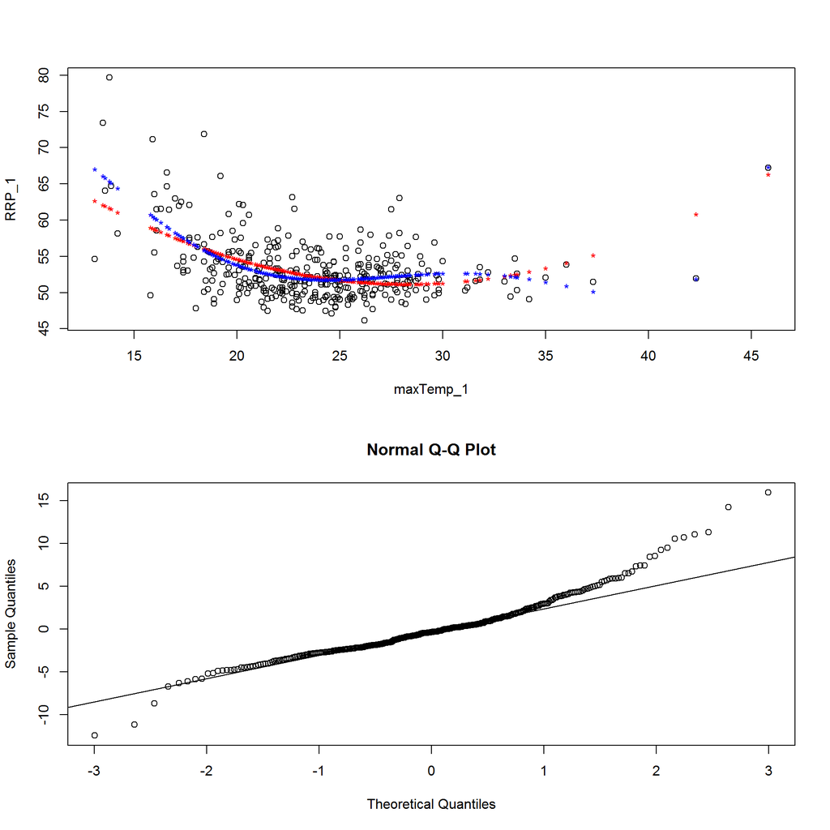

```r
plot(RRP_1~maxTemp_1)
points(maxTemp_1, nl2$fitted, pch='*', col='red')
points(maxTemp_1, nl5$fitted, pch='*', col='blue')

qqnorm(nl5$residuals); qqline(nl5$residuals)
```

Up to 5th degree the p value suggest the coefficients are predictive. The 10th degree model is clearly overfitting the data, couple of points on the tails are driving it. Up to the 5th degree the coefficients seem to have good predictive power and hence I think this 5th degree polinomial is a good model. We have studied about spline models in the last class and hence I would like to investigate if it has any better fit then this current model.

## Splines

I am using natural splines which enforces linearity on the tails (this would get rid of overfittign on the small data at the tails).

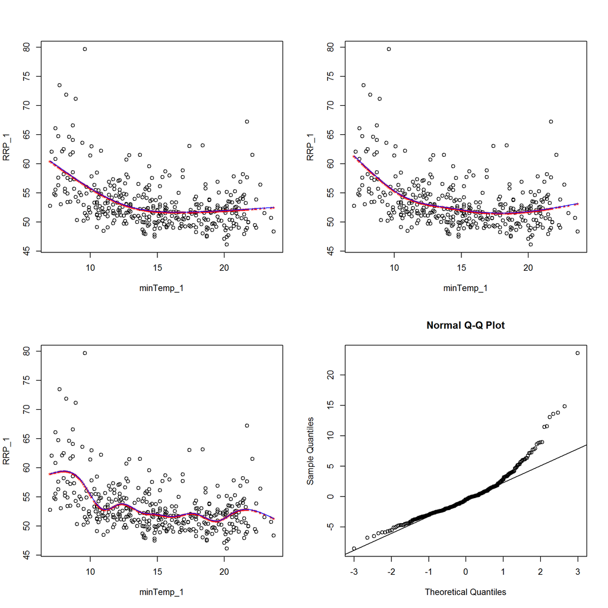

```r
library("splines")
par(mfrow=c(2,2))
splines3<-lm(RRP_1~ns(minTemp_1,df=3))
plot(minTemp_1,RRP_1)
points(minTemp_1, splines3$fitted, pch='*', col='red')
predpoints<-seq(min(minTemp_1), max(minTemp_1), length.out=300)
lines(predpoints, predict(splines3, data.frame(minTemp_1=predpoints)), col='blue')

splines5<-lm(RRP_1~ns(minTemp_1,df=5))
plot(minTemp_1,RRP_1)
points(minTemp_1, splines5$fitted, pch='*', col='red')
predpoints<-seq(min(minTemp_1), max(minTemp_1), length.out=300)
lines(predpoints, predict(splines5, data.frame(minTemp_1=predpoints)), col='blue')

splines10<-lm(RRP_1~ns(minTemp_1,df=10))
plot(minTemp_1,RRP_1)
points(minTemp_1, splines10$fitted, pch='*', col='red')
predpoints<-seq(min(minTemp_1), max(minTemp_1), length.out=300)
lines(predpoints, predict(splines10, data.frame(minTemp_1=predpoints)), col='blue')

qqnorm(splines5$residuals); qqline(splines5$residuals)
```

The 10th degree splines is clearly doing a good job at fitting to the datapints but it seems very erratic in the middle of the data which is due to overfitting. In my opinion the splines with 5 degrees of freedom looks like the best fit to the data without having random behaviour at middle or the tails. I will be using this model to predict new values. (df 10 is clearly overfitting)

## Comparing the models

```r
anova(lm(RRP_1~minTemp_1), lm(RRP_1~ns(minTemp_1,df=5)))
```

```
## Analysis of Variance Table
##
## Model 1: RRP_1 ~ minTemp_1
## Model 2: RRP_1 ~ ns(minTemp_1, df = 5)
##   Res.Df    RSS Df Sum of Sq      F    Pr(>F)
## 1    362 5545.1
## 2    358 4847.1  4    697.98 12.888 8.192e-10 ***
## ---
## Signif. codes:  0 '***' 0.001 '**' 0.01 '*' 0.05 '.' 0.1 ' ' 1
```

```r
anova(lm(RRP_1~poly(maxTemp_1, degree=5)), lm(RRP_1~ns(minTemp_1,df=5)))
```

```
## Analysis of Variance Table
##
## Model 1: RRP_1 ~ poly(maxTemp_1, degree = 5)
## Model 2: RRP_1 ~ ns(minTemp_1, df = 5)
##   Res.Df    RSS Df Sum of Sq F Pr(>F)
## 1    358 4255.2
## 2    358 4847.1  0   -591.83
```

```r
anova(lm(RRP_1~ns(minTemp_1,df=5)), lm(RRP_1~ns(minTemp_1,df=10)))
```

```
## Analysis of Variance Table
##
## Model 1: RRP_1 ~ ns(minTemp_1, df = 5)
## Model 2: RRP_1 ~ ns(minTemp_1, df = 10)
##   Res.Df    RSS Df Sum of Sq      F  Pr(>F)
## 1    358 4847.1
## 2    353 4698.5  5    148.57 2.2325 0.05067 .
## ---
## Signif. codes:  0 '***' 0.001 '**' 0.01 '*' 0.05 '.' 0.1 ' ' 1
```

It seems like both 5th degree polinomial and splines have good predictive power. I will be using the 5th degree splines to predict new data as it seems to have nicer behaviour at the tails.

## Predictions

I need to add new data to a dataframe whcih can then be fed to the predic function.

```r
new.data <- data.frame(minTemp_1=c(20.5,22.3,21.0,20.1,20.8,19.6,18.3))
predict(splines5, newdata=new.data,interval='prediction')
```

```
##        fit      lwr      upr
## 1 51.95761 44.67582 59.23940
## 2 52.60289 45.20785 59.99793
## 3 52.11551 44.83224 59.39878
## 4 51.84667 44.56148 59.13186
## 5 52.04998 44.76867 59.33128
## 6 51.73005 44.44252 59.01758
## 7 51.56020 44.28328 58.83713
```

## Weekdays Effect

Now checking for day-of-the-week effects:

```r
weekdays = as.factor((weekdays((Date_1))))
summary(weekdays)
```

```
##    Friday    Monday  Saturday    Sunday  Thursday   Tuesday Wednesday
##        51        52        52        52        52        53        52
```

```r
aggregate(RRP_1, by=list(weekdays(Date_1)), summary)
```

```
##     Group.1 x.Min. x.1st Qu. x.Median x.Mean x.3rd Qu. x.Max.
## 1    Friday  48.98     51.15    52.31  53.54     54.75  67.21
## 2    Monday  48.89     50.82    53.00  54.37     56.38  79.67
## 3  Saturday  47.94     50.10    51.48  52.11     53.26  73.45
## 4    Sunday  47.13     49.07    50.70  51.34     52.47  64.71
## 5  Thursday  47.69     51.56    52.32  53.60     54.66  71.86
## 6   Tuesday  46.15     51.56    52.81  53.99     56.15  64.64
## 7 Wednesday  47.50     51.02    52.34  53.57     55.51  71.15
```

```r
aggregate(RRP_1, by=list(weekdays(Date_1)), sd)
```

```
##     Group.1        x
## 1    Friday 3.844604
## 2    Monday 5.398159
## 3  Saturday 3.804461
## 4    Sunday 3.316730
## 5  Thursday 4.215594
## 6   Tuesday 4.093337
## 7 Wednesday 4.230697
```

```r
mu <- mean(RRP_1)
sdRRP <- sd(RRP_1)

mu +sdRRP; mu-sdRRP
```

```
## [1] 57.47695
```

```
## [1] 48.96014
```

## Does the day of the week have an affect on the price of electricity?

Let’s compare the price of electricity across the seven days of the week:

[figure not shown]

```r
AEMO$day <- weekdays(as.Date(AEMO$Date, '%d/%m/%Y'))
AEMO$maxtemp <- maxTemp
AEMO$mintemp <- minTemp
AEMO <- AEMO[-c(354),]
maxTemp <- maxTemp[-c(354)]
minTemp <- minTemp[-c(354)]
```

[figure not shown]

From this we can see that the weekend days have a slightly lower average than the others, so we now try to add a quintic model which takes into account the days of the week too:

```r
lmresult<-lm(AEMO$RRP~AEMO$day + poly(maxTemp, degree=5))
summary(lmresult)
```

```
##
## Call:
## lm(formula = AEMO$RRP ~ AEMO$day + poly(maxTemp, degree = 5))
##
## Residuals:
##      Min       1Q   Median       3Q      Max
## -12.9885  -1.9388  -0.3852   1.5820  15.3953
##
## Coefficients:
##                            Estimate Std. Error t value Pr(>|t|)
## (Intercept)                 53.4320     0.4659 114.693  < 2e-16 ***
## AEMO$dayMonday               1.1102     0.6520   1.703 0.089490 .
## AEMO$daySaturday            -1.3668     0.6547  -2.088 0.037540 *
## AEMO$daySunday              -2.2953     0.6528  -3.516 0.000495 ***
## AEMO$dayThursday             0.2248     0.6567   0.342 0.732249
## AEMO$dayTuesday              0.8272     0.6516   1.269 0.205108
## AEMO$dayWednesday           -0.0105     0.6534  -0.016 0.987185
## poly(maxTemp, degree = 5)1 -26.9977     3.2966  -8.190 4.89e-15 ***
## poly(maxTemp, degree = 5)2  35.1253     3.2920  10.670  < 2e-16 ***
## poly(maxTemp, degree = 5)3 -13.8134     3.3339  -4.143 4.29e-05 ***
## poly(maxTemp, degree = 5)4  13.1157     3.2956   3.980 8.38e-05 ***
## poly(maxTemp, degree = 5)5   9.9349     3.3161   2.996 0.002930 **
## ---
## Signif. codes:  0 '***' 0.001 '**' 0.01 '*' 0.05 '.' 0.1 ' ' 1
##
## Residual standard error: 3.286 on 352 degrees of freedom
## Multiple R-squared:  0.4227, Adjusted R-squared:  0.4046
## F-statistic: 23.43 on 11 and 352 DF,  p-value: < 2.2e-16
```

From the summary we can see that being a SUnday or not has a signifcant effect on the price of electricity. This makes sense contextually; it is probable that people are less active on sundays and use less electricity.

## Predicting future values

First, for ease, I predict the price of electricty for the first week of the new year using the quintic polynomial regression mdel:

```r
lmresult<-lm(AEMO$RRP~ poly(maxTemp, degree=5))
new.temps <- data.frame(maxTemp=c(20.5,22.3,21.0,20.1,20.8,19.6,18.3))
predict(lmresult, newdata=new.temps,interval='prediction')
```

```
##        fit      lwr      upr
## 1 53.38599 46.58369 60.18829
## 2 52.21708 45.41822 59.01595
## 3 52.97307 46.17272 59.77341
## 4 53.76820 46.96349 60.57291
## 5 53.12972 46.32872 59.93072
## 6 54.31235 47.50340 61.12129
## 7 56.07670 49.25057 62.90282
```

Now we encorporate the days of the week to see if that makes a difference:

```r
Daysofweek<- AEMO$day
lmresult<-lm(AEMO$RRP~ Daysofweek + poly(maxTemp, degree=5))
new.temps <- data.frame(maxTemp=c(20.5,22.3,21.0,20.1,20.8,19.6,18.3), Daysofweek=c("Wednesday", "Thursday", "Friday", "Saturday", "Sunday", "Monday", "Tuesday" ))
predict(lmresult, newdata=new.temps,interval='prediction')
```

```
##        fit      lwr      upr
## 1 53.58622 47.04756 60.12487
## 2 52.59981 46.06348 59.13614
## 3 53.16472 46.63152 59.69791
## 4 52.62949 46.08746 59.17152
## 5 51.03330 44.49937 57.56723
## 6 55.67476 49.13291 62.21661
## 7 57.22617 50.66083 63.79151
```

# Statistics and Financial Data Analysis - Problem Sheet 1

Prof. Samuel Cohen

Gabor Bakos | Student ID: 1031893

17/10/2016

## Note

Unfortunately due to another dealine being pushed forward I ran out of time and only did question one of the problem sheet. I will be trying to do the rest of the problem sheet after submission.

## Imprting Data

Download the files AEMOPriceDataSimple.csv and SydTemp.csv, along with the R script PS1Readin.R (which loads and formats the data). The AEMO ???le contains daily average Regional Reference Price (RRP) for New South Wales (Australia), and is adapted from http://www.aemo.com.au/Electricity/Data. The data gives the daily average spot price over 2013. The SydTemp file gives daily maximum and minimum temperatures at Observatory Hill, Sydney since 1859, and is taken from the main weather observatory http://www.bom.gov.au/climate/data-services/.

```r
library("quantmod")
AEMO<-read.csv("AEMOPriceDataSimple.csv")
SydTemp<-read.csv("SydTemp.csv")
minTemp<-SydTemp$Minimum.temperature..Degree.C.
maxTemp<-SydTemp$Maximum.temperature..Degree.C.
maxTemp<-maxTemp[SydTemp$Year==2013]
minTemp<-minTemp[SydTemp$Year==2013]
```

```r
#Assigning the variables with appropriate names:
maxTemp<-maxTemp[!is.na(maxTemp)]
minTemp<-minTemp[!is.na(minTemp)]
Date<-as.Date(AEMO$Date, '%d/%m/%y')
AEMO$day <- weekdays(as.Date(AEMO$Date, '%d/%m/%Y'))
RRP<-AEMO$RRP
```

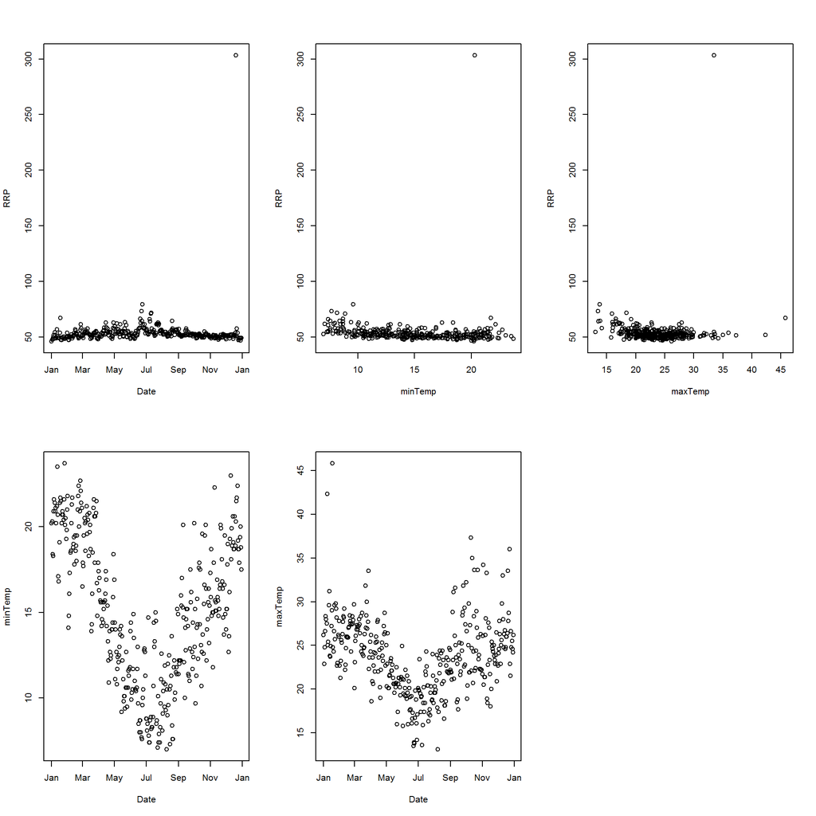

```r
#Some basic plots:
par(mfrow=c(2,3))
plot(Date,RRP)
plot(minTemp,RRP)
plot(maxTemp,RRP)
plot(Date,minTemp)
plot(Date,maxTemp)
```

```r
#Basic analysis
par(mfrow=c(2,3))
summary(RRP)
```

```
##    Min. 1st Qu.  Median    Mean 3rd Qu.    Max.
##   46.15   50.55   52.26   53.90   54.74  303.10
```

```r
sd(RRP) #standard deviation
```

```
## [1] 13.75435
```

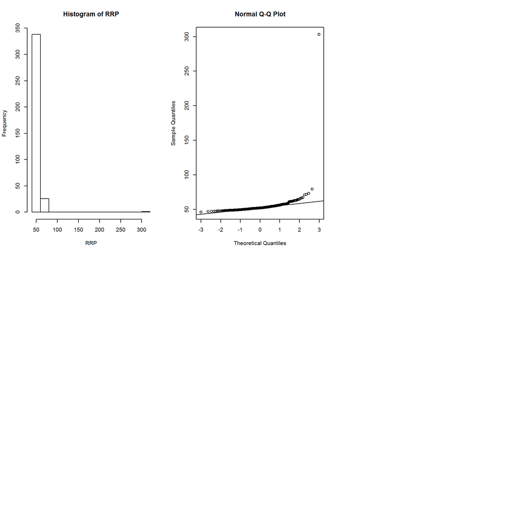

```r
hist(RRP) #histogram
qqnorm(RRP); qqline(RRP) #normal qq plot
```

There is an extereme outlier which makes it impossible to fit a good model the normal data accurately. I decided to remove this outlier but kept it in mind that extremes like that can happen occasionally.(We are trying to predict the normal day price given by weather conditions not predict what happens in extreme conditions.)

```r
#IGNORE outlier
par(mfrow=c(2,3))
Date_1<-Date[-354]
RRP_1<-RRP[-354]
minTemp_1<-minTemp[-354]
maxTemp_1<-maxTemp[-354]

summary(RRP_1)
```

```
##    Min. 1st Qu.  Median    Mean 3rd Qu.    Max.
##   46.15   50.52   52.25   53.22   54.73   79.67
```

```r
sd(RRP_1) #standard deviation
```

```
## [1] 4.258405
```

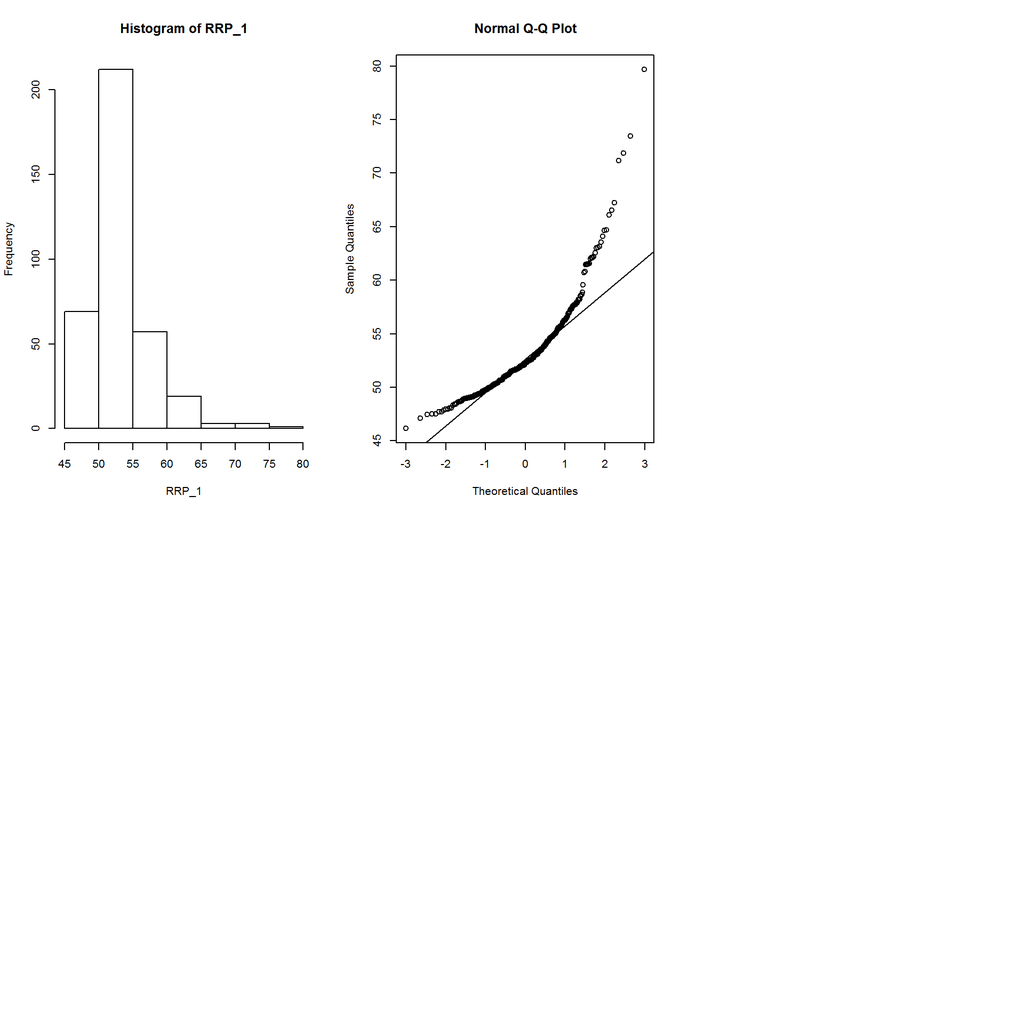

```r
hist(RRP_1) #histogram
qqnorm(RRP_1); qqline(RRP_1) #normal qq plot
```

Plotting the RRP against date, min and max temperatures and min and max temperatures against data as well.

```
##                   RRP   minTemp_1   maxTemp_1
## RRP        1.00000000 -0.04561863 -0.05255668
## minTemp_1 -0.04561863  1.00000000  0.71213266
## maxTemp_1 -0.05255668  0.71213266  1.00000000
```

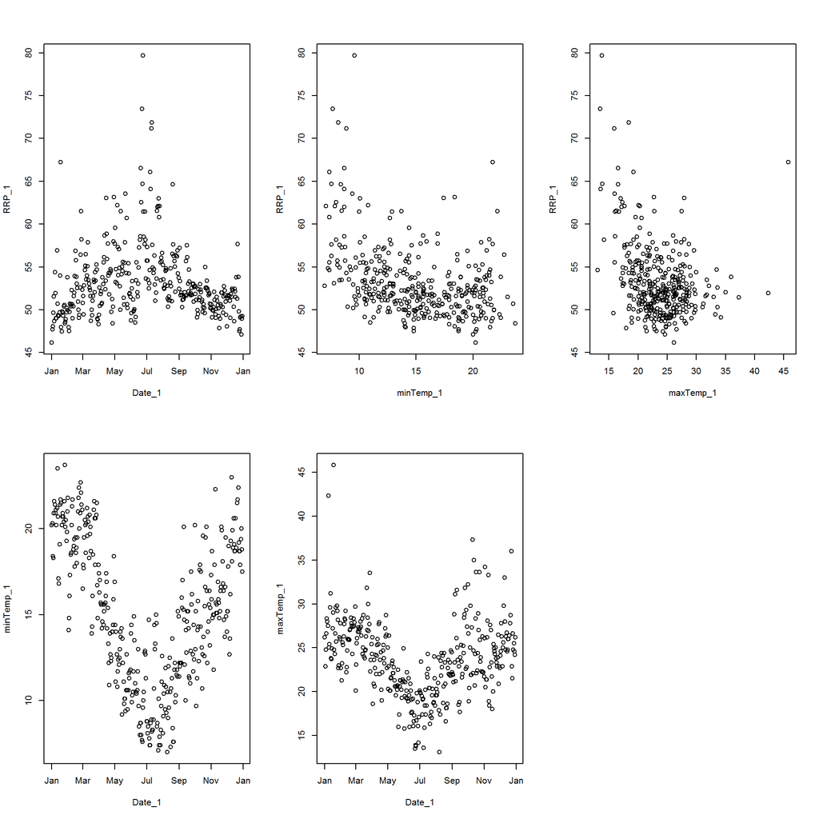

```r
par(mfrow=c(2,3))
plot(Date_1,RRP_1)
plot(minTemp_1,RRP_1)
plot(maxTemp_1,RRP_1)
plot(Date_1,minTemp_1)
plot(Date_1,maxTemp_1)

cor(cbind(RRP,minTemp_1,maxTemp_1))
```

## Linear Models

As a first step I am trying out linear models agains min temperature , max temperature and both.

```r
#maxminusminTemp_1<-maxTemp_1-minTemp_1
#minusmaxTemp_1<-minTemp_1-maxTemp_1
par(mfrow=c(2,3))


fit1<-lm(RRP_1~minTemp_1)
fit2<-lm(RRP_1~maxTemp_1)
fit3<-lm(RRP_1~minTemp_1+maxTemp_1)
#fit4<-lm(RRP_1~maxminusminTemp_1)
#fit5<-lm(RRP_1~minusmaxTemp_1)

summary(fit1)
```

```
##
## Call:
## lm(formula = RRP_1 ~ minTemp_1)
##
## Residuals:
##    Min     1Q Median     3Q    Max
## -6.335 -2.626 -0.885  1.407 24.271
##
## Coefficients:
##             Estimate Std. Error t value Pr(>|t|)
## (Intercept) 59.26364    0.76261   77.71  < 2e-16 ***
## minTemp_1   -0.40260    0.04892   -8.23 3.42e-15 ***
## ---
## Signif. codes:  0 '***' 0.001 '**' 0.01 '*' 0.05 '.' 0.1 ' ' 1
##
## Residual standard error: 3.914 on 362 degrees of freedom
## Multiple R-squared:  0.1576, Adjusted R-squared:  0.1553
## F-statistic: 67.74 on 1 and 362 DF,  p-value: 3.418e-15
```

```r
summary(fit2)
```

```
##
## Call:
## lm(formula = RRP_1 ~ maxTemp_1)
##
## Residuals:
##     Min      1Q  Median      3Q     Max
## -7.1787 -2.4978 -0.7148  1.4711 23.3039
##
## Coefficients:
##             Estimate Std. Error t value Pr(>|t|)
## (Intercept)  60.7606     1.1772  51.614  < 2e-16 ***
## maxTemp_1    -0.3184     0.0489  -6.513 2.47e-10 ***
## ---
## Signif. codes:  0 '***' 0.001 '**' 0.01 '*' 0.05 '.' 0.1 ' ' 1
##
## Residual standard error: 4.034 on 362 degrees of freedom
## Multiple R-squared:  0.1049, Adjusted R-squared:  0.1024
## F-statistic: 42.42 on 1 and 362 DF,  p-value: 2.471e-10
```

```r
summary(fit3)
```

```
##
## Call:
## lm(formula = RRP_1 ~ minTemp_1 + maxTemp_1)
##
## Residuals:
##     Min      1Q  Median      3Q     Max
## -6.4858 -2.6116 -0.9112  1.3875 23.7861
##
## Coefficients:
##             Estimate Std. Error t value Pr(>|t|)
## (Intercept) 60.30324    1.14502  52.666  < 2e-16 ***
## minTemp_1   -0.34230    0.06962  -4.917 1.34e-06 ***
## maxTemp_1   -0.08212    0.06750  -1.217    0.225
## ---
## Signif. codes:  0 '***' 0.001 '**' 0.01 '*' 0.05 '.' 0.1 ' ' 1
##
## Residual standard error: 3.911 on 361 degrees of freedom
## Multiple R-squared:  0.1611, Adjusted R-squared:  0.1564
## F-statistic: 34.65 on 2 and 361 DF,  p-value: 1.71e-14
```

```
## [1] 0.7119827
```

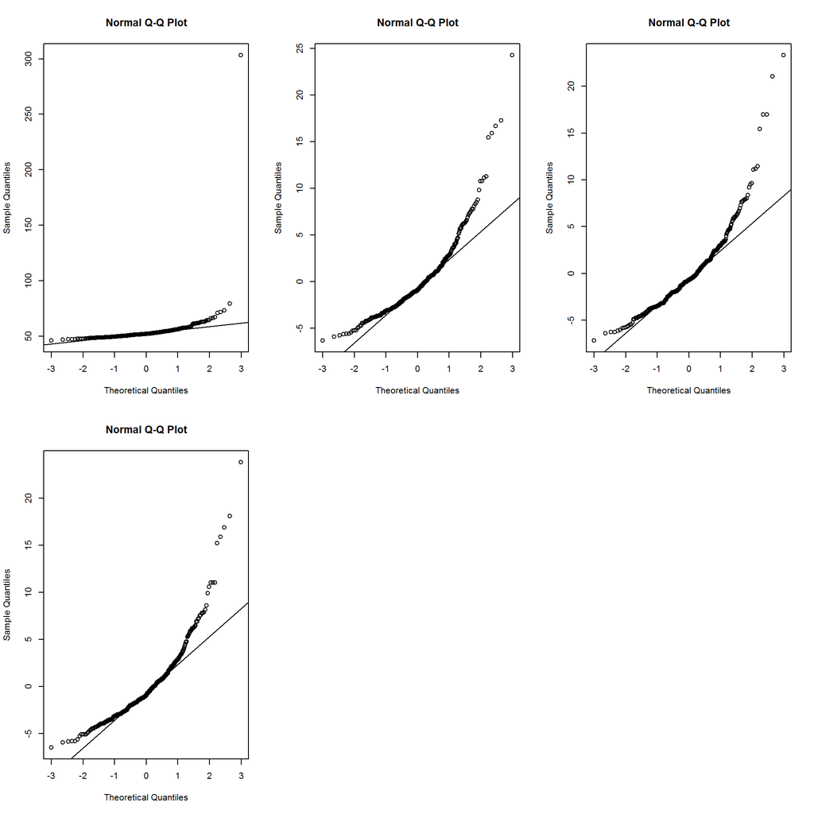

```r
#summary(fit4)
#summary(fit5)

#Normality checking#
qqnorm(RRP); qqline(RRP)
qqnorm(fit1$residuals); qqline(fit1$residuals)
qqnorm(fit2$residuals); qqline(fit2$residuals)
qqnorm(fit3$residuals); qqline(fit3$residuals)
cor(minTemp_1,maxTemp_1)
```

When trying to predict with both min and max temperatures the min is more predictive than max (there is a very high correlation between the min and max temperature hence using only one is sufficient).

The QQ plots suggest that the relation between temperature and the RRP might be non linear.

## Polinomial fits

I have tried couple of polinomial fits up to degree 10, to see whether it fits the data better.

```r
#higher dimensional
par(mfrow=c(2,1))

#higher dimensional
nl2<-lm(RRP_1~poly(maxTemp_1, degree=2))
nl5<-lm(RRP_1~poly(maxTemp_1, degree=5))
nl10<-lm(RRP_1~poly(maxTemp_1, degree=10))
summary(nl2)
```

```
##
## Call:
## lm(formula = RRP_1 ~ poly(maxTemp_1, degree = 2))
##
## Residuals:
##     Min      1Q  Median      3Q     Max
## -9.4060 -2.4868 -0.2823  1.7724 17.9674
##
## Coefficients:
##                              Estimate Std. Error t value Pr(>|t|)
## (Intercept)                   53.2185     0.1886 282.213  < 2e-16 ***
## poly(maxTemp_1, degree = 2)1 -26.2752     3.5978  -7.303 1.81e-12 ***
## poly(maxTemp_1, degree = 2)2  34.9202     3.5978   9.706  < 2e-16 ***
## ---
## Signif. codes:  0 '***' 0.001 '**' 0.01 '*' 0.05 '.' 0.1 ' ' 1
##
## Residual standard error: 3.598 on 361 degrees of freedom
## Multiple R-squared:  0.2901, Adjusted R-squared:  0.2862
## F-statistic: 73.77 on 2 and 361 DF,  p-value: < 2.2e-16
```

```r
summary(nl5)
```

```
##
## Call:
## lm(formula = RRP_1 ~ poly(maxTemp_1, degree = 5))
##
## Residuals:
##      Min       1Q   Median       3Q      Max
## -12.4366  -2.1971  -0.3703   1.4710  15.9369
##
## Coefficients:
##                              Estimate Std. Error t value Pr(>|t|)
## (Intercept)                   53.2185     0.1807 294.505  < 2e-16 ***
## poly(maxTemp_1, degree = 5)1 -26.2752     3.4476  -7.621 2.27e-13 ***
## poly(maxTemp_1, degree = 5)2  34.9202     3.4476  10.129  < 2e-16 ***
## poly(maxTemp_1, degree = 5)3 -12.8083     3.4476  -3.715 0.000236 ***
## poly(maxTemp_1, degree = 5)4  13.1627     3.4476   3.818 0.000159 ***
## poly(maxTemp_1, degree = 5)5   8.9600     3.4476   2.599 0.009739 **
## ---
## Signif. codes:  0 '***' 0.001 '**' 0.01 '*' 0.05 '.' 0.1 ' ' 1
##
## Residual standard error: 3.448 on 358 degrees of freedom
## Multiple R-squared:  0.3536, Adjusted R-squared:  0.3445
## F-statistic: 39.16 on 5 and 358 DF,  p-value: < 2.2e-16
```

```r
summary(nl10)
```

```
##
## Call:
## lm(formula = RRP_1 ~ poly(maxTemp_1, degree = 10))
##
## Residuals:
##      Min       1Q   Median       3Q      Max
## -12.7968  -2.2146  -0.3352   1.3625  16.4447
##
## Coefficients:
##                                Estimate Std. Error t value Pr(>|t|)
## (Intercept)                     53.2185     0.1791 297.174  < 2e-16 ***
## poly(maxTemp_1, degree = 10)1  -26.2752     3.4167  -7.690 1.48e-13 ***
## poly(maxTemp_1, degree = 10)2   34.9202     3.4167  10.221  < 2e-16 ***
## poly(maxTemp_1, degree = 10)3  -12.8083     3.4167  -3.749 0.000208 ***
## poly(maxTemp_1, degree = 10)4   13.1627     3.4167   3.853 0.000139 ***
## poly(maxTemp_1, degree = 10)5    8.9600     3.4167   2.622 0.009109 **
## poly(maxTemp_1, degree = 10)6   -2.6586     3.4167  -0.778 0.437020
## poly(maxTemp_1, degree = 10)7    3.8972     3.4167   1.141 0.254786
## poly(maxTemp_1, degree = 10)8   -1.9453     3.4167  -0.569 0.569478
## poly(maxTemp_1, degree = 10)9    8.5058     3.4167   2.490 0.013252 *
## poly(maxTemp_1, degree = 10)10  -6.0065     3.4167  -1.758 0.079616 .
## ---
## Signif. codes:  0 '***' 0.001 '**' 0.01 '*' 0.05 '.' 0.1 ' ' 1
##
## Residual standard error: 3.417 on 353 degrees of freedom
## Multiple R-squared:  0.374,  Adjusted R-squared:  0.3563
## F-statistic: 21.09 on 10 and 353 DF,  p-value: < 2.2e-16
```

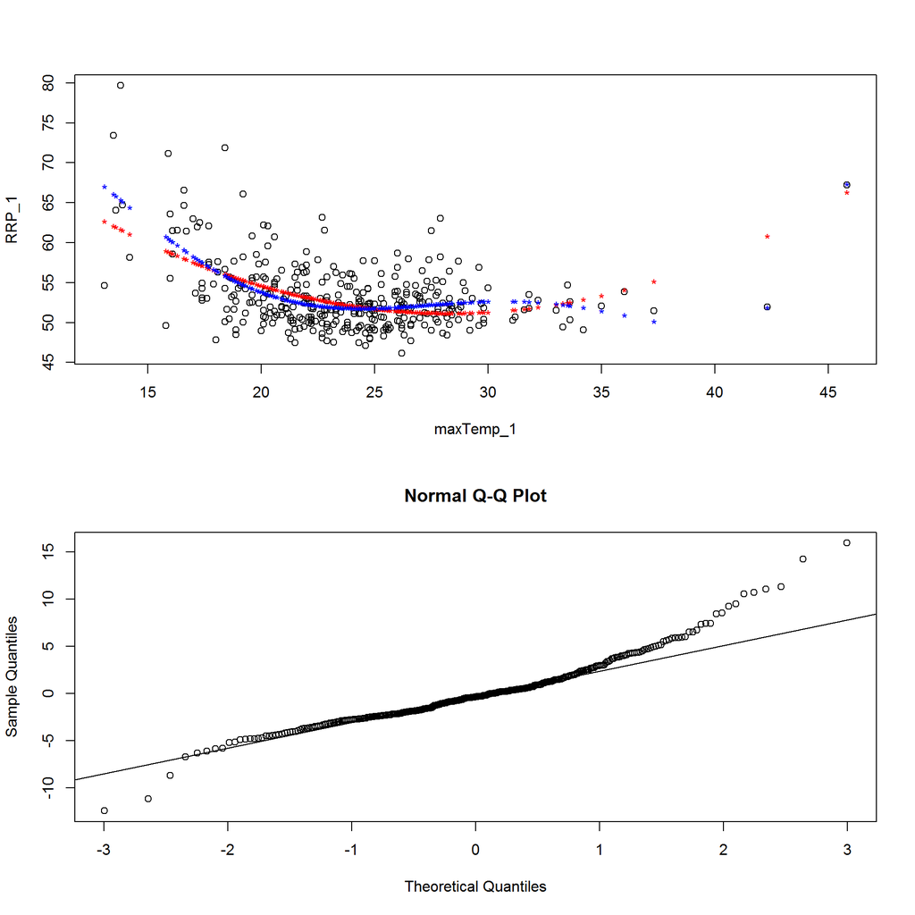

```r
plot(RRP_1~maxTemp_1)
points(maxTemp_1, nl2$fitted, pch='*', col='red')
points(maxTemp_1, nl5$fitted, pch='*', col='blue')

qqnorm(nl5$residuals); qqline(nl5$residuals)
```

Up to 5th degree the p value suggest the coefficients are predictive. The 10th degree model is clearly overfitting the data, couple of points on the tails are driving it. Up to the 5th degree the coefficients seem to have good predictive power and hence I think this 5th degree polinomial is a good model. We have studied about spline models in the last class and hence I would like to investigate if it has any better fit then this current model.

## Splines

I am using natural splines which enforces linearity on the tails (this would get rid of overfittign on the small data at the tails).

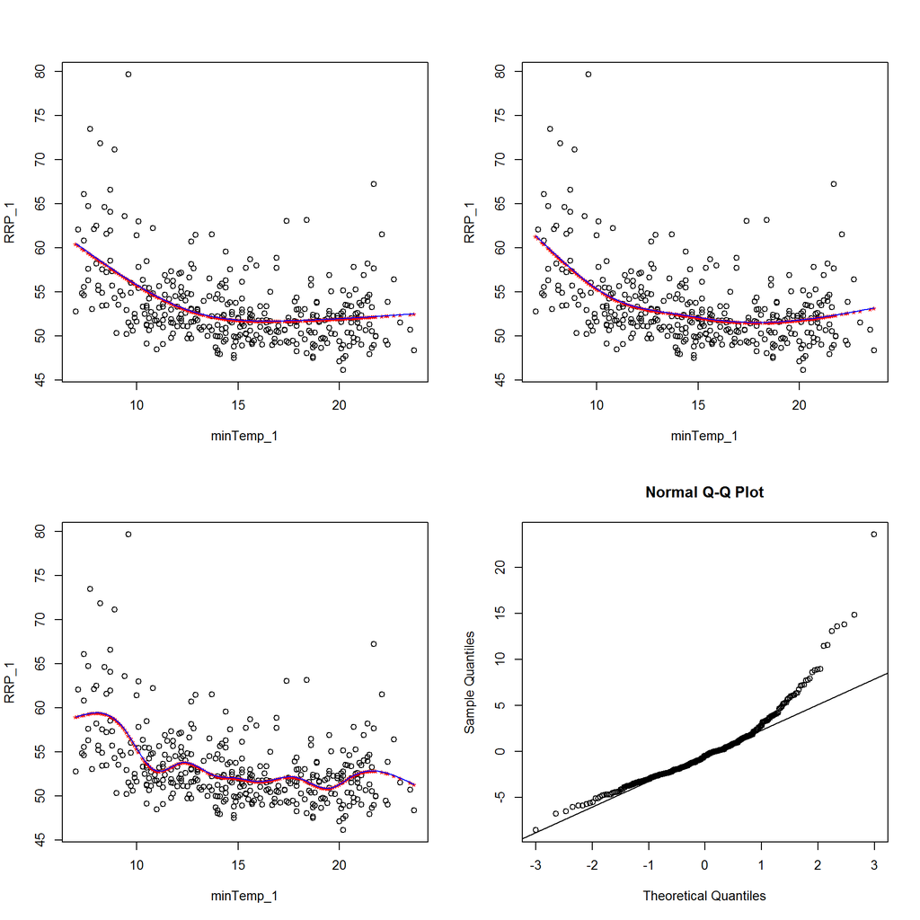

```r
library("splines")
par(mfrow=c(2,2))
splines3<-lm(RRP_1~ns(minTemp_1,df=3))
plot(minTemp_1,RRP_1)
points(minTemp_1, splines3$fitted, pch='*', col='red')
predpoints<-seq(min(minTemp_1), max(minTemp_1), length.out=300)
lines(predpoints, predict(splines3, data.frame(minTemp_1=predpoints)), col='blue')

splines5<-lm(RRP_1~ns(minTemp_1,df=5))
plot(minTemp_1,RRP_1)
points(minTemp_1, splines5$fitted, pch='*', col='red')
predpoints<-seq(min(minTemp_1), max(minTemp_1), length.out=300)
lines(predpoints, predict(splines5, data.frame(minTemp_1=predpoints)), col='blue')

splines10<-lm(RRP_1~ns(minTemp_1,df=10))
plot(minTemp_1,RRP_1)
points(minTemp_1, splines10$fitted, pch='*', col='red')
predpoints<-seq(min(minTemp_1), max(minTemp_1), length.out=300)
lines(predpoints, predict(splines10, data.frame(minTemp_1=predpoints)), col='blue')

qqnorm(splines5$residuals); qqline(splines5$residuals)
```

The 10th degree splines is clearly doing a good job at fitting to the datapints but it seems very erratic in the middle of the data which is due to overfitting. In my opinion the splines with 5 degrees of freedom looks like the best fit to the data without having random behaviour at middle or the tails. I will be using this model to predict new values. (df 10 is clearly overfitting)

## Comparing the models

```r
anova(lm(RRP_1~minTemp_1), lm(RRP_1~ns(minTemp_1,df=5)))
```

```
## Analysis of Variance Table
##
## Model 1: RRP_1 ~ minTemp_1
## Model 2: RRP_1 ~ ns(minTemp_1, df = 5)
##   Res.Df    RSS Df Sum of Sq      F    Pr(>F)
## 1    362 5545.1
## 2    358 4847.1  4    697.98 12.888 8.192e-10 ***
## ---
## Signif. codes:  0 '***' 0.001 '**' 0.01 '*' 0.05 '.' 0.1 ' ' 1
```

```r
anova(lm(RRP_1~poly(maxTemp_1, degree=5)), lm(RRP_1~ns(minTemp_1,df=5)))
```

```
## Analysis of Variance Table
##
## Model 1: RRP_1 ~ poly(maxTemp_1, degree = 5)
## Model 2: RRP_1 ~ ns(minTemp_1, df = 5)
##   Res.Df    RSS Df Sum of Sq F Pr(>F)
## 1    358 4255.2
## 2    358 4847.1  0   -591.83
```

```r
anova(lm(RRP_1~ns(minTemp_1,df=5)), lm(RRP_1~ns(minTemp_1,df=10)))
```

```
## Analysis of Variance Table
##
## Model 1: RRP_1 ~ ns(minTemp_1, df = 5)
## Model 2: RRP_1 ~ ns(minTemp_1, df = 10)
##   Res.Df    RSS Df Sum of Sq      F  Pr(>F)
## 1    358 4847.1
## 2    353 4698.5  5    148.57 2.2325 0.05067 .
## ---
## Signif. codes:  0 '***' 0.001 '**' 0.01 '*' 0.05 '.' 0.1 ' ' 1
```

It seems like both 5th degree polinomial and splines have good predictive power. I will be using the 5th degree splines to predict new data as it seems to have nicer behaviour at the tails.

## Predictions

I need to add new data to a dataframe whcih can then be fed to the predic function.

```r
new.data <- data.frame(minTemp_1=c(20.5,22.3,21.0,20.1,20.8,19.6,18.3))
predict(splines5, newdata=new.data,interval='prediction')
```

```
##        fit      lwr      upr
## 1 51.95761 44.67582 59.23940
## 2 52.60289 45.20785 59.99793
## 3 52.11551 44.83224 59.39878
## 4 51.84667 44.56148 59.13186
## 5 52.04998 44.76867 59.33128
## 6 51.73005 44.44252 59.01758
## 7 51.56020 44.28328 58.83713
```

## Weekdays Effect

Now checking for day-of-the-week effects:

```r
weekdays = as.factor((weekdays((Date_1))))
summary(weekdays)
```

```
##    Friday    Monday  Saturday    Sunday  Thursday   Tuesday Wednesday
##        51        52        52        52        52        53        52
```

```r
aggregate(RRP_1, by=list(weekdays(Date_1)), summary)
```

```
##     Group.1 x.Min. x.1st Qu. x.Median x.Mean x.3rd Qu. x.Max.
## 1    Friday  48.98     51.15    52.31  53.54     54.75  67.21
## 2    Monday  48.89     50.82    53.00  54.37     56.38  79.67
## 3  Saturday  47.94     50.10    51.48  52.11     53.26  73.45
## 4    Sunday  47.13     49.07    50.70  51.34     52.47  64.71
## 5  Thursday  47.69     51.56    52.32  53.60     54.66  71.86
## 6   Tuesday  46.15     51.56    52.81  53.99     56.15  64.64
## 7 Wednesday  47.50     51.02    52.34  53.57     55.51  71.15
```

```r
aggregate(RRP_1, by=list(weekdays(Date_1)), sd)
```

```
##     Group.1        x
## 1    Friday 3.844604
## 2    Monday 5.398159
## 3  Saturday 3.804461
## 4    Sunday 3.316730
## 5  Thursday 4.215594
## 6   Tuesday 4.093337
## 7 Wednesday 4.230697
```

```r
mu <- mean(RRP_1)
sdRRP <- sd(RRP_1)

mu +sdRRP; mu-sdRRP
```

```
## [1] 57.47695
```

```
## [1] 48.96014
```

## Does the day of the week have an affect on the price of electricity?

Let’s compare the price of electricity across the seven days of the week:

[figure not shown]

```r
AEMO$day <- weekdays(as.Date(AEMO$Date, '%d/%m/%Y'))
AEMO$maxtemp <- maxTemp
AEMO$mintemp <- minTemp
AEMO <- AEMO[-c(354),]
maxTemp <- maxTemp[-c(354)]
minTemp <- minTemp[-c(354)]
```

[figure not shown]

From this we can see that the weekend days have a slightly lower average than the others, so we now try to add a quintic model which takes into account the days of the week too:

```r
lmresult<-lm(AEMO$RRP~AEMO$day + poly(maxTemp, degree=5))
summary(lmresult)
```

```
##
## Call:
## lm(formula = AEMO$RRP ~ AEMO$day + poly(maxTemp, degree = 5))
##
## Residuals:
##      Min       1Q   Median       3Q      Max
## -12.9885  -1.9388  -0.3852   1.5820  15.3953
##
## Coefficients:
##                            Estimate Std. Error t value Pr(>|t|)
## (Intercept)                 53.4320     0.4659 114.693  < 2e-16 ***
## AEMO$dayMonday               1.1102     0.6520   1.703 0.089490 .
## AEMO$daySaturday            -1.3668     0.6547  -2.088 0.037540 *
## AEMO$daySunday              -2.2953     0.6528  -3.516 0.000495 ***
## AEMO$dayThursday             0.2248     0.6567   0.342 0.732249
## AEMO$dayTuesday              0.8272     0.6516   1.269 0.205108
## AEMO$dayWednesday           -0.0105     0.6534  -0.016 0.987185
## poly(maxTemp, degree = 5)1 -26.9977     3.2966  -8.190 4.89e-15 ***
## poly(maxTemp, degree = 5)2  35.1253     3.2920  10.670  < 2e-16 ***
## poly(maxTemp, degree = 5)3 -13.8134     3.3339  -4.143 4.29e-05 ***
## poly(maxTemp, degree = 5)4  13.1157     3.2956   3.980 8.38e-05 ***
## poly(maxTemp, degree = 5)5   9.9349     3.3161   2.996 0.002930 **
## ---
## Signif. codes:  0 '***' 0.001 '**' 0.01 '*' 0.05 '.' 0.1 ' ' 1
##
## Residual standard error: 3.286 on 352 degrees of freedom
## Multiple R-squared:  0.4227, Adjusted R-squared:  0.4046
## F-statistic: 23.43 on 11 and 352 DF,  p-value: < 2.2e-16
```

From the summary we can see that being a SUnday or not has a signifcant effect on the price of electricity. This makes sense contextually; it is probable that people are less active on sundays and use less electricity.

## Predicting future values

First, for ease, I predict the price of electricty for the first week of the new year using the quintic polynomial regression mdel:

```r
lmresult<-lm(AEMO$RRP~ poly(maxTemp, degree=5))
new.temps <- data.frame(maxTemp=c(20.5,22.3,21.0,20.1,20.8,19.6,18.3))
predict(lmresult, newdata=new.temps,interval='prediction')
```

```
##        fit      lwr      upr
## 1 53.38599 46.58369 60.18829
## 2 52.21708 45.41822 59.01595
## 3 52.97307 46.17272 59.77341
## 4 53.76820 46.96349 60.57291
## 5 53.12972 46.32872 59.93072
## 6 54.31235 47.50340 61.12129
## 7 56.07670 49.25057 62.90282
```

Now we encorporate the days of the week to see if that makes a difference:

```r
Daysofweek<- AEMO$day
lmresult<-lm(AEMO$RRP~ Daysofweek + poly(maxTemp, degree=5))
new.temps <- data.frame(maxTemp=c(20.5,22.3,21.0,20.1,20.8,19.6,18.3), Daysofweek=c("Wednesday", "Thursday", "Friday", "Saturday", "Sunday", "Monday", "Tuesday" ))
predict(lmresult, newdata=new.temps,interval='prediction')
```

```
##        fit      lwr      upr
## 1 53.58622 47.04756 60.12487
## 2 52.59981 46.06348 59.13614
## 3 53.16472 46.63152 59.69791
## 4 52.62949 46.08746 59.17152
## 5 51.03330 44.49937 57.56723
## 6 55.67476 49.13291 62.21661
## 7 57.22617 50.66083 63.79151
```